# WABS Method to estimate prob of collision

# 14 Particular crossings

The simpler model is clearly better. So we fix on **LOGA** using `TTBL_SPD:AADT` only. This raises the question of why these crossings are predicted differently by the **LOGR** model chosen. Only one of these, Steele Lane, is predicted lower by **LOGR** than WABS.

```r
wh=glm.spdxaadt_data[which(abs(glm.spdxaadt_data$gap) >= 0.05),"RANK"]
mutate (dataf, L = glm.spdxaadt_data$L,
                  gap = glm.spdxaadt_data$gap  )[ wh, ] %>%
  mutate ( name = substr(paste0(CITY, "; ",substr(ROAD, 1, 16)),1,30), W = round(PRED_COLLS,4) ) %>%
  select ( RANK, name, W, L, gap, C, TTBL_SPD, AADT, TOT_TRN, HWYLNS, TOT_TRK ) %>%
  arrange (desc ( gap)) %>% gt
```

| RANK | name | W | L | gap | C | TTBL_SPD | AADT | TOT_TRN | HWYLNS | TOT_TRK |
| --- | --- | --- | --- | --- | --- | --- | --- | --- | --- | --- |
| 5 | SANTAROSA; PINER_ROAD | 0.0485 | 0.1964 | 0.1479 | 0 | 79 | 23900 | 64 | 4 | 1 |
| 4 | SANTAROSA; COLLEGE_AVENUE | 0.0494 | 0.1697 | 0.1203 | 0 | 60 | 26900 | 64 | 4 | 2 |
| 16 | PETALUMA; CORONA_ROAD | 0.0371 | 0.1189 | 0.0818 | 0 | 79 | 13810 | 60 | 2 | 1 |
| 31 | SONOMA; SEARSPOINT/ST-37 | 0.0212 | 0.0994 | 0.0782 | 0 | 25 | 35600 | 6 | 2 | 1 |
| 9 | SANTAROSA; GUERNEVILLE_ROAD | 0.0426 | 0.1190 | 0.0764 | 0 | 40 | 27300 | 64 | 2 | 2 |
| 2 | SANTAROSA; STEELE_LANE | 0.1293 | 0.0680 | -0.0613 | 0 | 70 | 8100 | 64 | 3 | 1 |

We note that Sears Point and St 37 crossing actually has 4 lanes of traffic, as a look at Google Maps shows. It seems that the somewhat higher probability imputed by L might be justified, although we cannot support inclusion of `HWYLNS` in the **LOGR** model.

Similarly Guerneville Rd has 4 highway lanes, though the database shows only 2. It has lower `TTBL_SPD` than College Ave, but higher `AADT` by a little. This would make it most similar to College Ave. We would expect a prediction higher for College Ave, and both methods get that, though the WABS difference is minimal.

# 15 Confidence intervals for predicted probabilities

We calculate 95% confidence intervals for the predictions from the interactions model to show how precise the predictions should be thought. We would expect that the WABS predictions should be within the 95% confidence interval for the LOGR predictions. Otherwise the WABS prediction could be anomalous. We do not have information on confidence intervals for the WABS predictions to see if they overlap those for LOGR.

```r
pr = predict(glm.spdxaadt, type="response", se.fit=TRUE)
confint = round(data.frame(W = dataf$PRED_COLLS,
                           L = pr$fit,
                           gap=glm.spdxaadt_data$gap,
                           lwr= pr$fit - 1.96*pr$se.fit,
                           upr = pr$fit + 1.96 * pr$se.fit),4
                ) %>%
  mutate ( clen = upr - lwr,
           rank=dataf$RANK,
           name=paste0(dataf$CITY,"; ",substr(dataf$ROAD,1,20) ) )
confint[wh,]
```

```
##         W      L     gap    lwr    upr   clen rank                        name
## 2  0.1293 0.0680 -0.0613 0.0141 0.1218 0.1077    2      SANTAROSA; STEELE_LANE
## 4  0.0494 0.1697  0.1203 0.0147 0.3247 0.3100    4   SANTAROSA; COLLEGE_AVENUE
## 5  0.0485 0.1964  0.1479 0.0122 0.3806 0.3684    5       SANTAROSA; PINER_ROAD
## 9  0.0426 0.1190  0.0764 0.0181 0.2199 0.2018    9 SANTAROSA; GUERNEVILLE_ROAD
## 16 0.0371 0.1189  0.0818 0.0181 0.2197 0.2016   16       PETALUMA; CORONA_ROAD
## 31 0.0212 0.0994  0.0782 0.0181 0.1806 0.1625   31    SONOMA; SEARSPOINT/ST-37
```

Only for Steele Lane does the WABS prediction fall outside the 95% confidence limits for the L prediction. What is special about Steele Lane? A picture of the intersection from Google Maps is shown here: [Picture](https://goo.gl/maps/HyDXqU8J5LG2) .

While there are only 3 lanes of traffic, the inner lane is a left turn lane into Coffey which crosses the tracks. This perhaps encourages cars waiting for the left turn, and not wanting to miss the red light cycle at Coffee, to chance waiting in the crossing for the turn. With train timetable speeds of 70 here, and no knowledge of the light cycle, trains might not be able to stop; drivers, not knowing this, would be taken unawares by a train that could not stop. The confidence limits give us additional support for the **LOGR** model, though not necessarily in preference to the WABS model.

# 16 Conclusions

We have independently modeled the WABS data for the cycle ending in November 2018, and have obtained a logistic regression model. It predicts the probability of a collision at each crossing during a one year period by using two of the predictors in the WABS data set, `TTBL_SPD` and `AADT`. These are the timetable speed of the scheduled trains, and the average auto daily traffic at the crossing. The variables `TOT_TRN` and `HWYLNS`, the total number of trains per day, and the number of highway lanes at the crossing were found not to improve the model, as was also true of the discrete crossing type variable `WD`.

The model obtained regresses C upon the interaction term TTBL_SPD*AADT alone. Thus there is a complex relation between the predictors.

An analysis of these crossings shows that of the 6, two have erroneous data in the HWYLNS field in WABS data. This was discovered by inspecting the crossing via Google Maps interactive view.

However these errata would not impact the predictions made by the **LOGA** model. We do not know whether the WABS predictions took the erroneous values into account.

# 17 Predicting the number of accidents in a year.

Assume that at crossings accident rates are independent; this is likely on a long linear line such as SMART. In that case we might add the collision probabilities to obtain the number of accidents in a year for the whole line.

The WABS method predicts almost 1.84 accidents per year; the **LOGR** method predicts 3 accidents per year. Last year (2018) there were 3 accidents at crossings on SMART. We could predict that there would be 3 again this year, if no changes are made at crossings.

```r
 sapply (list(glm.spdxaadt_data$W, glm.spdxaadt_data$L), sum)
```

```
## [1] 1.8368 3.0005
```

# 18 Acknowledgements

The author thanks Steve Birdlebough for calling this interesting problem and the WABS dataset to his attention.

# 19 References

[1] WABS dataset

# 20 Appendix A Univariate logistic regressions

Next we try `TOT_TRN`, the next most significant variable. We plot the distribution of gaps.

This variable skews gaps to the right, estimating in excess of the WABS estimates. But a look at the predicted values shows a certain amount of discretization, since the TOT_TRN predictor has only a few discrete values. This makes it not a good predictor to include.

Finally we try `AADT` on its own. We plot the distribution of the gaps.

Again there are relatively few values of the prediction, they tend to be low, and the busy intersections tend to be much lower.

The plots appear below.

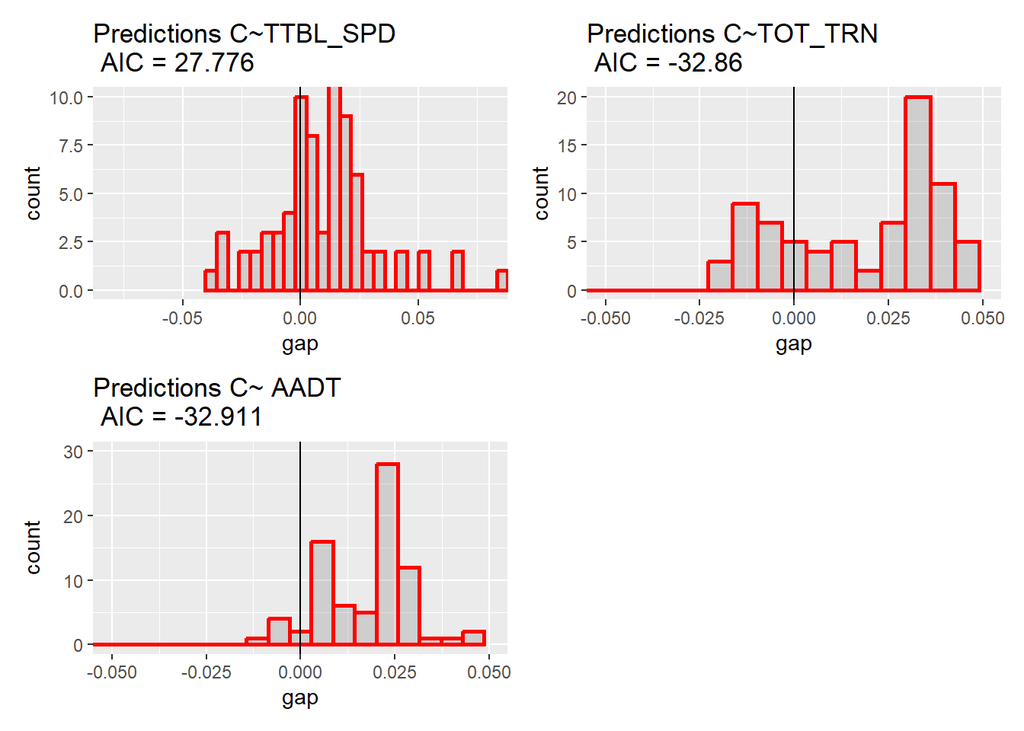

Comparisons of WABS and single-predictor LOGR predictions

```r
list(g1,g2,g3) %>% wrap_plots(nrow=2, ncol=2)
```

# 21 Appendix C Neural network prediction

We now use a simple neural network to predict the probabilities of accident at each crossing. We use the nnet routine in the caret package. Such a routine uses the data to fire adjacent nodes in the net at random, based on random numbers generated internally. Because we need to seed the neural network with a random number we cannot be assured we will get the same predictions each time. However, after we establish that the neural network works we can then bootstrap its results to get confidence intervals on the predictions. Start by setting the random number generation seed to a specific repeatable number. For comparison we select the same 3 variables we chose above. Since there are only 3 collisions, there could be difficulty training the neural net.

We use a neural network from the `nnet` package with feature extraction using PCA.

We can display the predicted probabilities with the WABS and **LOGR** predictions for comparison.

```r
print(mutate( out, NNET=round(probs$`1`,4 ) ) )
```

```
##                               name   WABS    LOGR   NNET
## 1             SANTAROSA; HEARN_AVE 0.1711 0.30700 0.1070
## 2           SANTAROSA; STEELE_LANE 0.1293 0.26425 0.0888
## 3      PETALUMA; WASHINGTON_STREET 0.0504 0.24901 0.0660
## 4        SANTAROSA; COLLEGE_AVENUE 0.0494 0.19704 0.0939
## 5            SANTAROSA; PINER_ROAD 0.0485 0.14239 0.1096
## 6   ROHNERTPARK; GOLF_COURSE_DRIVE 0.0464 0.10823 0.0760
## 7            SANRAFAEL; 4TH_STREET 0.0458 0.09945 0.0728
## 8       SANRAFAEL; N_SANPEDRO_ROAD 0.0455 0.09902 0.0711
## 9      SANTAROSA; GUERNEVILLE_ROAD 0.0426 0.09146 0.0774
## 10         PETALUMA; EAST_D_STREET 0.0424 0.08986 0.0648
## 11           SANTAROSA; 3RD_STREET 0.0423 0.08493 0.0613
## 12      SANTAROSA; SAN_MIGUEL_ROAD 0.0412 0.08308 0.0945
## 13           SANTAROSA; BARHAM_AVE 0.0400 0.08175 0.0942
## 14               NOVATO; GRANT_AVE 0.0379 0.08109 0.0733
```

[output cut: 66 more lines]

We compare the neural network predictions with those of **LOGR** graphically.

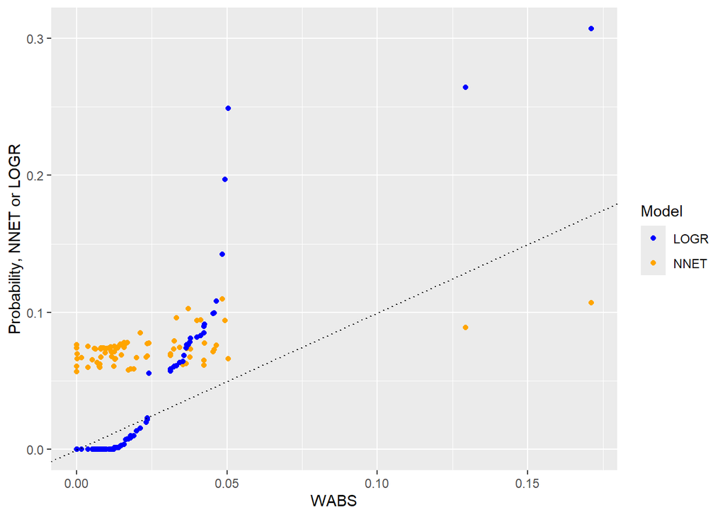

```r
mutate( out, NNET=round(probs$`1`,4 ) )  %>% ggplot()+
  geom_point(aes(WABS, NNET, color="NNET")) +
  geom_point(aes(WABS, LOGR, color="LOGR")) +
  scale_color_manual(values=c("blue","orange"), name="Model")+
  geom_abline(aes(intercept=0, slope=1), linetype="dotted") +
  labs(y="Probability, NNET or LOGR")
```

For zero or low `WABS` predictions, `LOGR` is right in line, but above .025 WABS predicts lower; NNET predicts uniformly higher except for the two cases above a WABS prediction of 10.

A neural net with feature extraction seems like it is not as useful as our **LOGA** model.